# Assignment #1

Michael L. Davies

2023-01-20

# Project Description and Context

The data are global climate data and include the latitude and longitude of the climate station, its elevation, and the yearly average temperature in degrees Celsius.

Raw Data File: `temperature.csv`

```r
temperature_df <-
  read_csv('data/temperature.csv') |>
  janitor::clean_names() |>
  select(cntry_name, name, year, elev, lat, lon) |>
  filter(elev != -999)

temperature_df |>
  arrange(cntry_name) |>
  head() |>
  knitr::kable()
```

| cntry_name | name | year | elev | lat | lon |
| --- | --- | --- | --- | --- | --- |
| Albania | SHKODRA | 15.0323 | 43 | 42.10 | 19.53 |
| Albania | TIRANA | 15.1901 | 89 | 41.33 | 19.78 |
| Albania | VLORE | 16.5708 | 1 | 40.47 | 19.48 |
| Albania | KORCA | 10.1633 | 889 | 40.60 | 20.77 |
| Algeria | AOULEF | 25.9916 | 290 | 27.10 | 1.10 |
| Algeria | OUALLEN | 27.8011 | 347 | 24.60 | 1.20 |

**Exercise Instructions:**

The ultimate objective is to determine how well elevation predicts annual temperature in this region, and to use the regression model to predict annual temperature for Front Royal, VA.

**Study Questions:**

# Question 1.

> What is the regression (beta) coefficient for elevation? (0.5 pts)
- The model produces a beta = -0.00308

```r
# check for missing values
# temperature_df |>
#         filter(is.na(elev))
#
# temperature_df |>
#         filter(is.na(elev))

# Specification for a linear regression model
lm_spec <- linear_reg() |>
  # setting mode just to be explicit. Not necessary here
  set_mode("regression") |>
  set_engine("lm")

# Fit the model
lm_fit <- lm_spec |>
  fit(year ~ elev, data = temperature_df)

lm_fit |>
  broom::tidy()
```

```
## # A tibble: 2 × 5
##   term        estimate std.error statistic  p.value
##   <chr>          <dbl>     <dbl>     <dbl>    <dbl>
## 1 (Intercept) 14.7      0.156         94.4 0
## 2 elev        -0.00308  0.000223     -13.8 1.67e-42
```

```r
# glance(lm_fit)
```

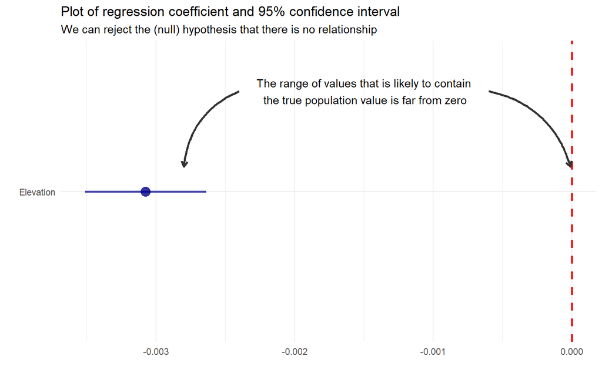

```r
arrows <-
  tibble(
    x1 = c(-0.002, -0.001),
    x2 = c(-0.0028, -0.00001),
    y1 = c(1.4, 1.4),
    y2 = c(1.1, 1.2)
  )

tidy(lm_fit) |>
  relabel_predictors(elev = "Elevation") |>
  dwplot(
    dot_args = list(size = 4, color = "darkblue", alpha = .8),
    whisker_args = list(size = 1, color = "darkblue", alpha = .7),
    vline = geom_vline(xintercept = 0,
                       color = "red",
                       linetype = 2,
                       size = 1)) +
  annotate("text",
           x = -0.0015,
           y = 1.4,
           label = "The range of values that is likely to contain\n the true population value is far from zero") +
  geom_curve(aes(x = -0.0024, y = 1.4, xend = -0.0028, yend = 1.1),
    arrow = arrow(length = unit(0.08, "inch")), size = 1,
    color = "gray20", curvature = 0.3) +
  geom_curve(aes(x = -0.0006, y = 1.4, xend = -0.00001, yend = 1.1),
    arrow = arrow(length = unit(0.08, "inch")), size = 1,
    color = "gray20", curvature = -0.3) +
  labs(
    title = 'Plot of regression coefficient and 95% confidence interval',
    subtitle = 'We can reject the (null) hypothesis that there is no relationship')
```

# Question 2.

> What is the predicted change in annual temperature, with a 100 m increase in elevation? (1 pt)
- With a 100m **increase** in elevation, the model predicts 100 * -0.00308, or a **decrease** in mean annual temperature by 0.31$^\circ$C.

# Question 3.

> How much variation in temperature is explained by elevation in the US? (1 pt)

**Filtering data for US observations only**

- Limiting the data to the U.S. and re-running the model obtains an R-Squared of 0.13. This suggests that, within the U.S., approximately 13% of the variance in mean annual temperatures can be explained by elevation.

```r
# subset to only US
lm_fit_US <- lm_spec |>
  fit(year ~ elev,
      data = temperature_df |>
        filter(cntry_name == "United States"))

lm_fit_US |>
  pluck("fit") |>
  summary()
```

```
##
## Call:
## stats::lm(formula = year ~ elev, data = data)
##
## Residuals:
##      Min       1Q   Median       3Q      Max
## -25.2034  -2.9572  -0.3244   3.4308  11.3942
##
## Coefficients:
##               Estimate Std. Error t value Pr(>|t|)
## (Intercept) 12.8691433  0.1664956   77.29   <2e-16 ***
## elev        -0.0030350  0.0001998  -15.19   <2e-16 ***
## ---
## Signif. codes:  0 '***' 0.001 '**' 0.01 '*' 0.05 '.' 0.1 ' ' 1
##
## Residual standard error: 4.725 on 1534 degrees of freedom
## Multiple R-squared:  0.1307, Adjusted R-squared:  0.1302
## F-statistic: 230.7 on 1 and 1534 DF,  p-value: < 2.2e-16
```

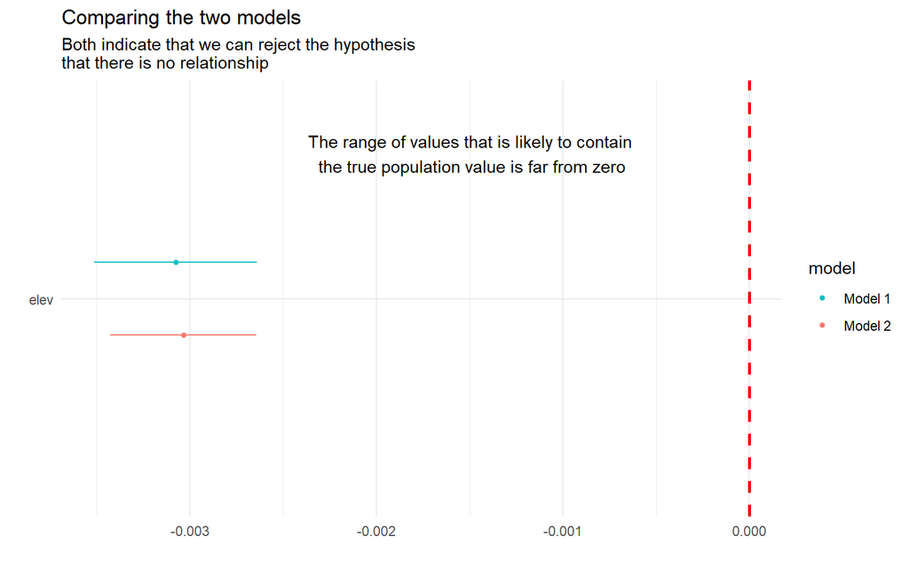

```r
dwplot(
  list(lm_fit, lm_fit_US),
  vline = geom_vline(
    xintercept = 0,
    color = "red",
    linetype = 2,
    size = 1)) +
  annotate(
    "text",
    x = -0.0015,
    y = 1.4,
    label = "The range of values that is likely to contain\n the true population value is far from zero") +
  labs(
    title = 'Comparing the two models',
    subtitle = 'Both indicate that we can reject the hypothesis\nthat there is no relationship')
```

# Question 4.

> Using ggplot, generate a scatterplot of temperature vs. elevation data. Include your fitted regression line and give appropriate labels for both axes. (1 pt)

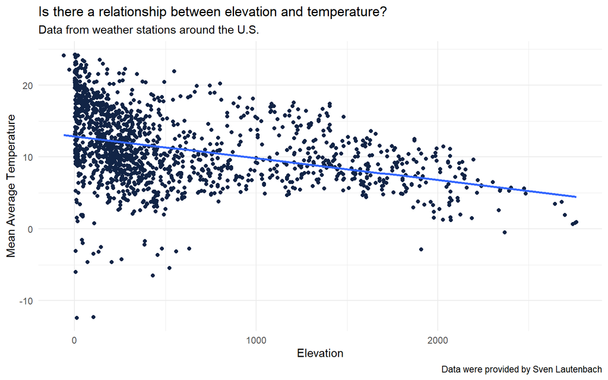

```r
temperature_df |>
  filter(cntry_name == "United States") |>
  ggplot(aes(x = elev, y = year)) +
  geom_point(
    shape = "circle",
    size = 1.5,
    color = "#112446") +
  geom_smooth(method = lm, se = FALSE) +
  labs(x = "Elevation",
       y = "Mean Average Temperature",
       title = 'Is there a relationship between elevation and temperature?',
       subtitle = 'Data from weather stations around the U.S.',
       caption = 'Data were provided by Sven Lautenbach') +
  theme_minimal()
```

# Question 5.

```r
# create prediction data and predict
new_data = tibble(elev = 170)

# point estimate
predict(lm_fit_US,
        new_data = new_data)
```

```
## # A tibble: 1 × 1
##   .pred
##   <dbl>
## 1  12.4
```

```r
# confidence interval
predict(lm_fit,
        new_data = new_data,
        type = "conf_int")
```

```
## # A tibble: 1 × 2
##   .pred_lower .pred_upper
##         <dbl>       <dbl>
## 1        13.9        14.5
```